# Milestone

jmtaysom

December 28, 2015

This is the milestone report for the Johns Hopkins Data Science capstone. In this project we are using data from swiftkey to try to do next word predictions.

```r
library(R.utils)
library(quanteda)
setwd("~/Capstone")
```

After downloading and extracting the data it was examined to determine the size of each dataset.

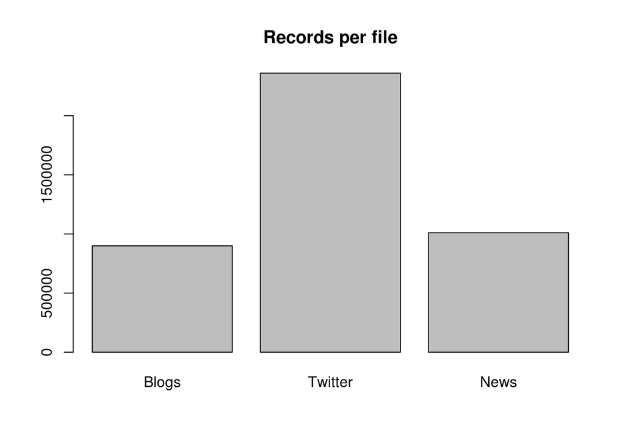

```r
blog.lines <- countLines('final/en_US/en_US.blogs.txt')
twit.lines <- countLines('final/en_US/en_US.twitter.txt')
news.lines <- countLines('final/en_US/en_US.news.txt')
x = c('Blogs', "Twitter", "News")
y = c(blog.lines,twit.lines,news.lines)
df <- data.frame(x,y)
barplot(df$y, names.arg = df$x, main='Records per file')
```

The plot shows that in the blogs, twitter, and news datasets there are 899288, 2360148, and 1010242 lines of data.

Since the datasets are so large it is possible to use a part of each to understand what the whole dataset looks like. Using the first 100,000 lines from each, unigrams were created to see what words were used in each sample. The following shows how many unique words are used in each dataset.

```r
con <- file('final/en_US/en_US.blogs.txt',"r")
blogs <- readLines(con, 100000)
unigram.b <- tokenize(toLower(blogs), removePunct = TRUE, removeNumbers = TRUE, ngrams =1)
unigram.b <- unlist(unigram.b)
unigram.b <- unigram.b[!duplicated(unigram.b)]
rm(blogs)
con <- file('final/en_US/en_US.twitter.txt',"r")
twitter <- readLines(con, 100000)
unigram.t <- tokenize(toLower(twitter), removePunct = TRUE, removeNumbers = TRUE, ngrams =1)
unigram.t <- unlist(unigram.t)
unigram.t <- unigram.t[!duplicated(unigram.t)]
rm(twitter)
con <- file('final/en_US/en_US.news.txt',"r")
news <- readLines(con, 100000)
unigram.n <- tokenize(toLower(news), removePunct = TRUE, removeNumbers = TRUE, ngrams =1)
unigram.n <- unlist(unigram.n)
unigram.n <- unigram.n[!duplicated(unigram.n)]
rm(news)
print(length(unigram.b))
```

```
## [1] 112030
```

```r
print(length(unigram.t))
```

```
## [1] 61826
```

```r
print(length(unigram.n))
```

```
## [1] 105857
```

After understanding how many unique words were in each dataset I created a dataset of trigrams or words that come in sets of three in a row to see how frequently certain combinations of words existed in the datasets. Below is a bar chart showing that after the first couple most frequent combinations the following trigrams slowly decrease in frequency of use.

```r
tf <- read.table('tf_100k.txt')
```

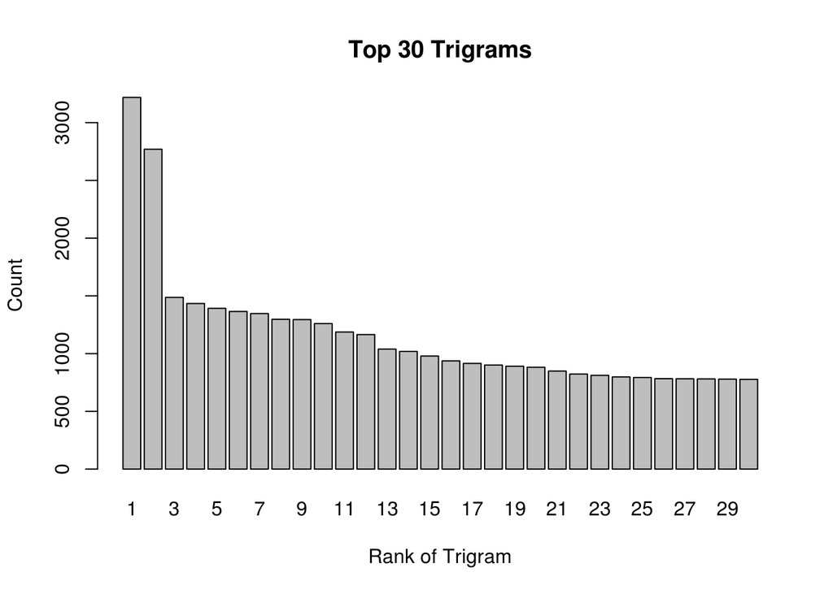

```r
tf <- tf[order(-tf$tf),]
tf.sub <- tf[1:30,]
tf.sub <- cbind(tf.sub, 1:30)
barplot(tf.sub$tf, names.arg = tf.sub$`1:30`, main = 'Top 30 Trigrams', xlab='Rank of Trigram', ylab='Count')
```

Below is the five most common n-grams as digrams (2 word), trigrams (3 word), and quadgrams (4 word).

```r
tf2 <- read.table('tf2_100k.txt',nrows = 5)
tf3 <- read.table('tf3_100k.txt',nrows = 5)
tf4 <- read.table('tf4_100k.txt',nrows = 5)
print(tf2)
```

```
##          X1  X2
## 1455226  of the
## 1058464  in the
## 2162408  to the
## 1481651  on the
## 792285  for the
```

```r
print(tf3)
```

```
##            X1  X2  X3
## 3328850   one  of the
## 194579      a lot  of
## 4879453    to  be   a
## 4536353   the end  of
## 1874937 going  to  be
```

```r
print(tf4)
```

```
##    V1   V2    V3   V4
## 1 the  end    of  the
## 2  at  the   end   of
## 3 the rest    of  the
## 4 for  the first time
## 5  at  the  same time
```

Using the three n-gram datasets it is possible to predict the next word in a sentance. Using the previous known words of a sentance you can try to use the quadgram data to find the most frequent next word. If there is not a quadram that matches the last three known words then you use the last two known words with the trigram data or last word with digram data.